# Phylogenetics

The likelihood of a tree, and the ancestors within it

## Last time

Any model of sequence evolution is a rate matrix $Q$, and $P(t) = e^{Qt}$ gives us its transition probabilities

With $P(t)$, we calculated the likelihood of the divergence between **two** sequences

But most questions in biology involve **many** sequences, related by a **tree**

# Trees

## Tree terms

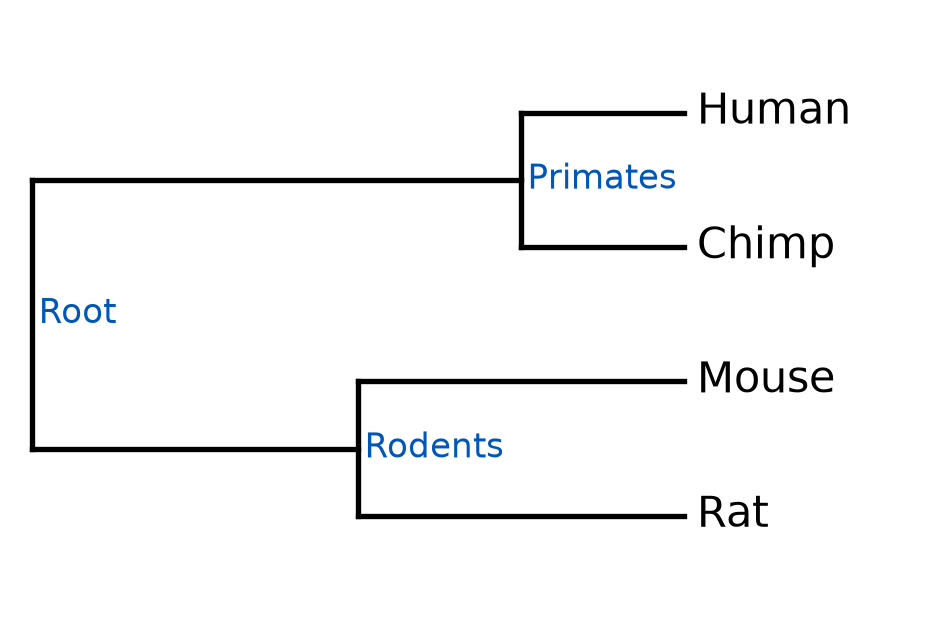

| Term | Meaning |
| --- | --- |
| *Tip nodes* | The sequences we have |
| *Internal nodes* | Their ancestors (no data!) |
| *Branch* | Line connecting nodes; a lineage evolving through time |
| *Branch length* | Expected substitutions per site (like $t$) |
| *Root* | The ancestor of everything |
| *Topology* | The branching pattern |
| *Clade* | An ancestor and all its descendants |

## Representing trees in computers

[*Newick format*](https://en.wikipedia.org/wiki/Newick_format): Parentheses hold descendants; numbers after colons are branch lengths

```
((Human:0.1,Chimp:0.1)Primates:0.3,(Mouse:0.2,Rat:0.2)Rodents:0.2)Root;
```

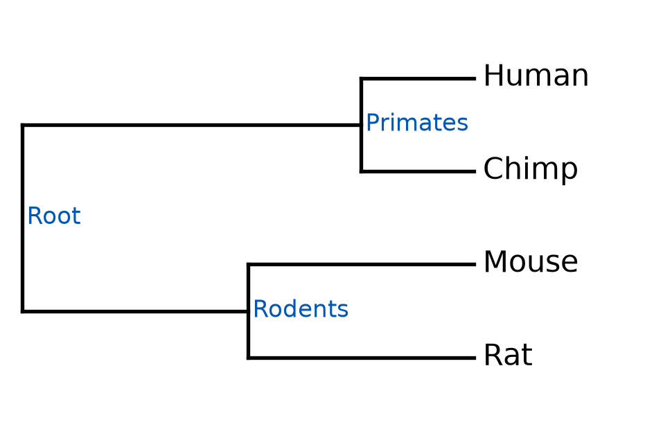

## Fun factoid

[Newick format](https://en.wikipedia.org/wiki/Newick_format) is named after Newick’s seafood restaurant in Dover, NH, where a committee of phylogeneticists met in 1986 to agree on the format

[figure not shown]

[Newick’s restaurant](https://www.i95exitguide.com/highway-gourmet/newicks-seafood-restaurant-newington-nh/)

## Representing trees in computers

In the exercise, we represent a tree as a **list of nodes** in *postorder*

Every node comes **after** its children, so the root is **last**

| Index | Name | Children | Length |
| --- | --- | --- | --- |
| 0 | Human |  | 0.1 |
| 1 | Chimp |  | 0.1 |
| 2 | Primates | 0, 1 | 0.3 |
| 3 | Mouse |  | 0.2 |
| 4 | Rat |  | 0.2 |
| 5 | Rodents | 3, 4 | 0.2 |
| 6 | Root | 2, 5 |  |

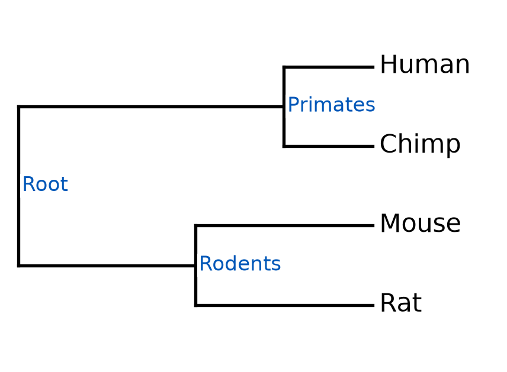

# How many trees?

## Tree space is enormous

Unrooted trees with $n$ tips:<sup>1</sup> $\;1 \times 3 \times 5 \times \cdots \times (2n - 5)$

| Tips | Unrooted trees | At 1 million trees per second |
| --- | --- | --- |
| 4 | 3 |  |
| 10 | 2,027,025 | 2 seconds |
| 15 | $7.9 \times 10^{12}$ | 92 days |
| 20 | $2.2 \times 10^{20}$ | 7 million years |
| 24 | $5.6 \times 10^{26}$ | $1.8 \times 10^{13}$ years |

We can’t try them all! Programs like IQ-TREE and RAxML use **heuristic search**: Make small rearrangements, and keep the ones that improve the likelihood

[^1]: Felsenstein (1978b)

# The likelihood of a tree

## We don’t have data from the ancestors

For two sequences, each site needed one lookup. *E.g.*, $P_{A \rightarrow G}(t)$

On a tree, we have to **add up** over every possible combination of bases at the internal nodes

An unrooted tree of 24 genomes has 22 internal nodes:

$4^{22} \approx 1.8 \times 10^{13}$ combinations, for **every site**

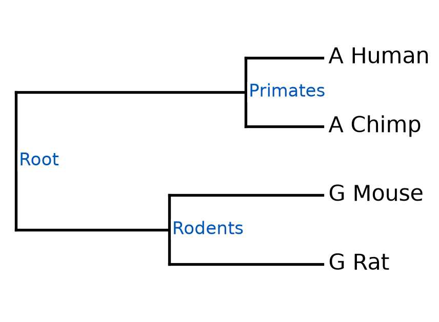

Question: Is there a way to avoid repeating work?

## Felsenstein’s pruning algorithm<sup>1</sup>

For each node, from the tips to the root, calculate its *conditional likelihoods*: $L_{\text{node}}(i)$ = probability of the data at the tips that descend from the node, **if** the node has base $i$

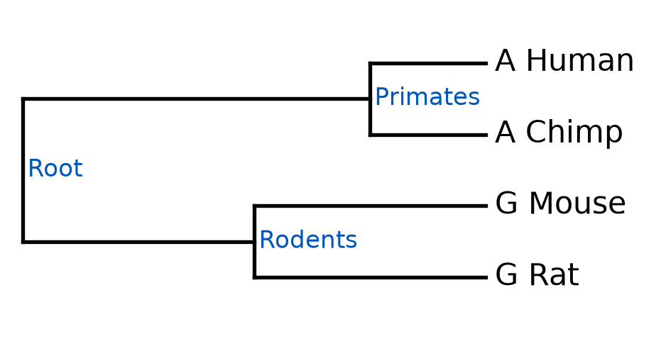

In doing this, the pruning algorithm follows *3 rules*

[^2]: Felsenstein (1981)

## Pruning algorithm Rule 1

At each **tip node**: the conditional likelihood is 1 for the base we observed and 0 for the other three bases

For example:

- The probability we observe an “`A`” in our data, given the true base is `A` = 1
- The probability we observe an “`A`” in our data, given the true base is `C` = 0

## Pruning algorithm Rule 2

At each **internal node**: For each base $i$, multiply together, over each child, the probability of getting the child’s data if the node has base $i$:

$$L_{\text{parent}}(i) = \prod_{\text{children}} \Big[ \sum_{j}
P_{ij}(t_{\text{child}}) \, L_{\text{child}}(j) \Big]$$

For example, if the parent ($i$) has `A` and the child ($j$) has `G`, the term in the sum is the probability that `A` evolved to `G` along the branch connecting them ($P_{A\rightarrow G}(t_{\text{child}})$), times the probability of the data at the tips that descend from the child, if the child has `G` ($L_{\text{child}}(G)$)

This is *dynamic programming* (like Needleman-Wunsch alignment!): Each $L_{\text{child}}$ is calculated once, and re-used for every base of the parent

## Pruning algorithm Rule 3

**At the root**, the likelihood of the site is the sum of the conditional likelihoods of the four bases, weighted by the base frequencies:

$L_{\text{site}} = \sum_{i} \pi_i \, L_{\text{root}}(i)$

This is a weighted average!

For example:

- For $i =$ `A`: The probability of the root having `A` ($\pi_A$), times the probability of the data at all the tips, if the root has `A` ($L_{\text{root}}(A)$)
- Add these products for all four bases

## Pruning, step by step

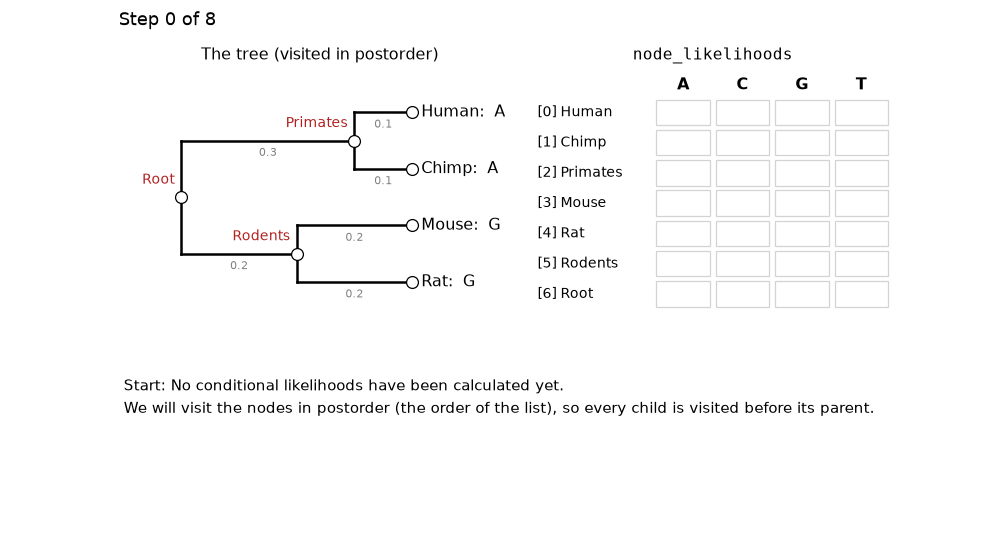

## Pruning algo for one site

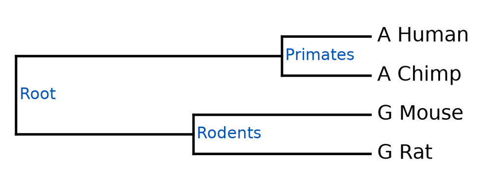

| Node | $L(\texttt{A})$ | $L(\texttt{C})$ | $L(\texttt{G})$ | $L(\texttt{T})$ |
| --- | --- | --- | --- | --- |
| Human, Chimp | 1 | 0 | 0 | 0 |
| Mouse, Rat | 0 | 0 | 1 | 0 |
| Primates | **0.8215** | 0.0010 | 0.0010 | 0.0010 |
| Rodents | 0.0034 | 0.0034 | **0.6797** | 0.0034 |
| Root | 0.0266 | 0.0029 | **0.0385** | 0.0029 |

$L_{\text{site}} = \frac{1}{4}(0.0266 + 0.0029 + 0.0385 + 0.0029) = 0.0177$

## Two shortcuts

- **Missing data**: A gap at a tip gives conditional likelihoods of $(1, 1, 1, 1)$
  - A site with **no** data has likelihood 1 ($\log 1 = 0$)
- **Site patterns**: Identical columns of the alignment have identical likelihoods
  - Four SARS-CoV-2 genomes: 29,903 sites, but only **56** patterns

# Which tree is best?

## SARS-CoV-2 lineages

| Name | Pango lineage<sup>1</sup> |
| --- | --- |
| Wuhan | `B` (the reference genome) |
| B.1 | `B.1` |
| Delta | `B.1.617.2` |
| Alpha | `B.1.1.7` |
| Gamma | `P.1` = `B.1.1.28.1` |
| Omicron | `BA.1.1` = `B.1.1.529.1.1` |

Lineage names work like addresses: `B.1.1` descends from `B.1`, which descends from `B`

[^3]: Rambaut et al. (2020)

## Three trees (unrooted) for four genomes

| Tree | Log-likelihood | Worse by |
| --- | --- | --- |
| 1: (Wuhan, Delta), (Alpha, Omicron) | **−42,433.11** |  |
| 2: (Wuhan, Alpha), (Delta, Omicron) | −42,444.08 | 10.96 |
| 3: (Wuhan, Omicron), (Delta, Alpha) | −42,447.15 | 14.04 |

How much does each kind of site favor Tree 1 over Tree 2?

| Kind of site | Sites | Tree 1 − Tree 2 |
| --- | --- | --- |
| Two pairs (*e.g.*, `AATT`) | 4 | **+12.49** |
| All four the same | 29,750 | +2.01 |
| One genome differs | 98 | −4.44 |
| Three or more bases | 2 | +0.93 |
| Missing data | 49 | −0.02 |

# Other methods

## Parsimony

- *Maximum parsimony*: Choose the tree that needs the **fewest changes**
- Fast, and intuitive: For the four genomes in the exercise, it would use **only** the “two pairs” sites
  - 3 favor Tree 1 and 1 favors Tree 2
  - All other sites are ignored!
- It ignores branch lengths and multiple hits, so it can be **positively misleading**: Long branches attract each other<sup>1</sup>
- Still useful when branches are **very short**: UShER<sup>2</sup> uses parsimony to place millions of SARS-CoV-2 genomes on a tree
[^4]: Felsenstein (1978a)
[^5]: Turakhia et al. (2021)

## Distance-based algorithms

- We will skip these today
- But you used two of these methods in Capstone 1!
  - *Neighbor-joining* and *UPGMA*

# Reconstructing ancestors

## What base did the root have?

The conditional likelihoods at the root also give us the probability of each base:

$$\Pr(\text{root has base } i \mid \text{data}) = \frac{\pi_i \,
L_{\text{root}}(i)}{\sum_{k} \pi_k \, L_{\text{root}}(k)}$$

For our example site:

| Base ($i$) | $L_\text{root}(i)$ | $\Pr(\text{root has base } i \mid \text{data})$ |
| --- | --- | --- |
| `A` | 0.0266 | 0.375 |
| `C` | 0.0029 | 0.042 |
| `G` | **0.0385** | **0.542** |
| `T` | 0.0029 | 0.042 |

Question: But what about the other ancestors?

## The pulley principle<sup>1</sup>

- For models like JC, K80, and HKY, the likelihood **doesn’t depend on where the root is**
- We can slide the root anywhere, like a rope over a pulley
- So, to reconstruct **any** ancestor: *Reroot* the tree at that ancestor, and use the probabilities at the root
[^6]: Felsenstein (1981)

## The ancestors of SARS-CoV-2 lineages

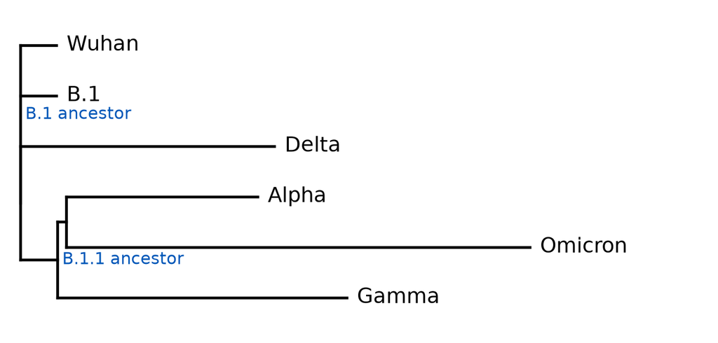

The maximum likelihood tree of six genomes (JC model)

## Reconstructed bases

| Position | Wuhan | B.1 | Delta | Alpha | Gamma | Omicron | B.1 ancestor | B.1.1 ancestor |
| --- | --- | --- | --- | --- | --- | --- | --- | --- |
| 3,037 | `C` | `T` | `T` | `T` | `T` | `T` | **`T`** | **`T`** |
| 14,408 | `C` | `T` | `T` | `T` | `T` | `T` | **`T`** | **`T`** |
| 23,403 (D614G) | `A` | `G` | `G` | `G` | `G` | `G` | **`G`** | **`G`** |
| 28,881–3 | `GGG` | `GGG` | `TGG` | `AAC` | `AAC` | `AAC` | **`GGG`** | **`AAC`** |

Every reconstruction has a probability of about 0.9999 or higher

## Confident is not the same as correct

- Alpha, Gamma, and Omicron all have **N501Y** (position 23,063, in the spike protein)
- So our reconstruction says the B.1.1 ancestor had it too (probability 0.9999)
- But N501Y arose **independently** in each of these lineages, favored by natural selection (*convergent evolution*)
- Our model knows nothing about selection, and our sample has no early B.1.1 genomes

## Summary

- A tree can be stored as a **list of nodes in postorder**
- The number of trees grows **astronomically**, so programs use a **heuristic search**
- **Felsenstein’s pruning algorithm** uses **dynamic programming** to calculate the likelihood of a tree from the tips to the root
- A few sites strongly favor one tree, but **every** site informs the branch lengths; **parsimony** uses only those few sites, and can be misled by long branches
- The root’s conditional likelihoods give **ancestral base probabilities**, and the **pulley principle** lets us reroot to reconstruct any ancestor

## In the exercise

1. `get_tip_names`: Loop over a tree’s list of nodes
2. `number_of_unrooted_trees`: Count tree space
3. `tip_likelihoods`, `combine_children`, `get_root_likelihoods`, `site_log_likelihood`: Build the pruning algorithm, one rule at a time
4. Compare three trees for four SARS-CoV-2 genomes
5. `root_state_probabilities` and `reconstruct_ancestor`: Reconstruct the ancestors of SARS-CoV-2 lineages

**Watch for**

Does rerooting the tree change its likelihood?

## Exercise

1. Log into [molab](https://molab.marimo.io/)
2. [Open the exercise in molab](https://molab.marimo.io/github/phyletica/intro-to-comp-bio/blob/main/notebooks/nb-08-phylogenetics/phylogenetics.py)
3. Click “Fork” button

# References

Felsenstein, Joseph. 1978a. “Cases in Which Parsimony or Compatibility Methods Will Be Positively Misleading.” *Systematic Zoology* 27 (4): 401–10. https://doi.org/10.2307/2412923.

Felsenstein, Joseph. 1978b. “The Number of Evolutionary Trees.” *Systematic Biology* 27 (1): 27–33.

Felsenstein, Joseph. 1981. “Evolutionary Trees from DNA Sequences: A Maximum Likelihood Approach.” *Journal of Molecular Evolution* 17: 368–76.

Rambaut, Andrew, Edward C. Holmes, Áine O’Toole, et al. 2020. “A Dynamic Nomenclature Proposal for SARS-CoV-2 Lineages to Assist Genomic Epidemiology.” *Nature Microbiology* 5 (11): 1403–7. https://doi.org/10.1038/s41564-020-0770-5.

Turakhia, Yatish, Bryan Thornlow, Angie S. Hinrichs, et al. 2021. “Ultrafast Sample Placement on Existing tRees (UShER) Enables Real-Time Phylogenetics for the SARS-CoV-2 Pandemic.” *Nature Genetics* 53 (6): 809–16. https://doi.org/10.1038/s41588-021-00862-7.

Yang, Ziheng, Sudhir Kumar, and Masatoshi Nei. 1995. “A New Method of Inference of Ancestral Nucleotide and Amino Acid Sequences.” *Genetics* 141 (4): 1641–50. https://doi.org/10.1093/genetics/141.4.1641.

## Acknowledgements

I drafted and iterated on these slides in collaboration with Anthropic’s Claude (Opus 5.5 model).